# Credit Card Fraud Detection Project Report

Jeny Patel

2025-07-08

# 1 Introduction

This project aims to detect fraudulent credit card transactions using machine learning models trained on a publicly available dataset from Kaggle. The dataset contains anonymized features and a highly imbalanced target variable

# 2 Dataset

The dataset contains transactions made by credit cards in September 2013 by European cardholders. It includes anonymized features from PCA transformations (V1 to V28), transaction amount, and the target variable `Class` (1 = Fraud, 0 = Non-fraud).

```r
# Load dataset from relative path
data <- fread("../data/creditcard.csv")

# Display dimensions and class distribution
dim(data)
```

```
## [1] 284807     31
```

```r
table(data$Class)
```

```
##
##      0      1
## 284315    492
```

# 3 Data Preprocessing

We first scaled the Amount feature and removed the Time column as it is not informative. The dataset was split into 80% training and 20% testing sets. Because of class imbalance, the training set was balanced using the ROSE technique.

```r
set.seed(123)

# Scale Amount and remove Time
data$Amount <- scale(data$Amount)
data <- data[, -"Time"]

# Split data into train and test sets
splitIndex <- createDataPartition(data$Class, p = 0.8, list = FALSE)
train <- data[splitIndex, ]
test <- data[-splitIndex, ]

# Balance training data using ROSE
train_balanced <- ROSE(Class ~ ., data = train, seed = 123)$data
table(train_balanced$Class)
```

```
##
##      0      1
## 114086 113760
```

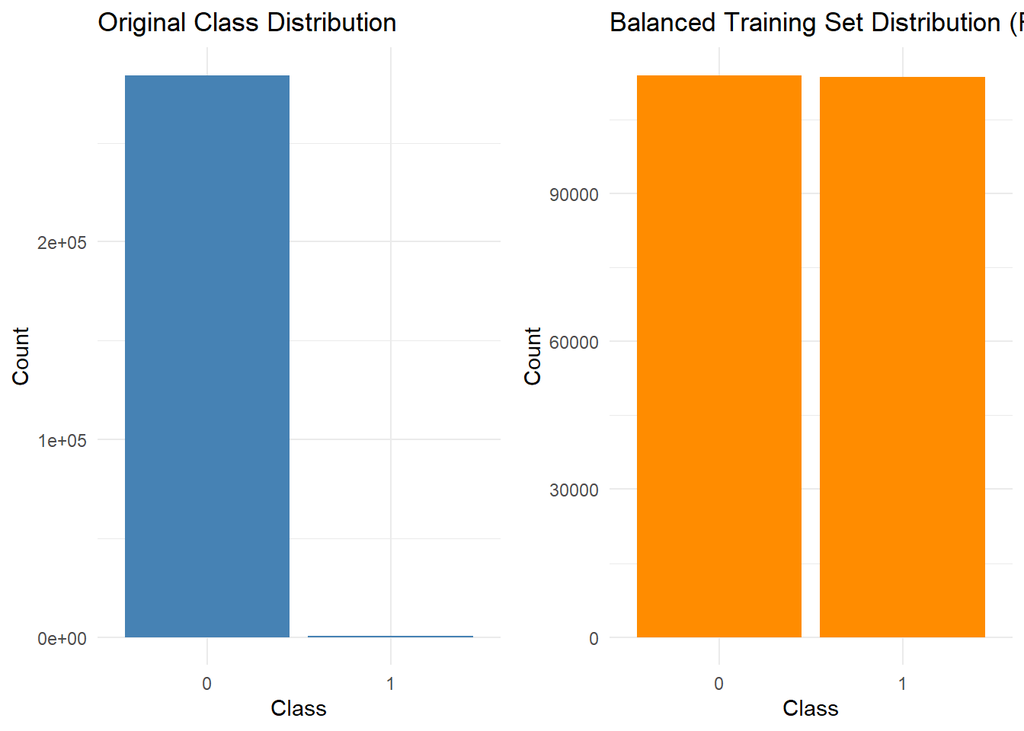

```r
# Visualize class distribution before and after balancing
library(gridExtra)

p1 <- ggplot(data, aes(x = factor(Class))) +
  geom_bar(fill = "steelblue") +
  ggtitle("Original Class Distribution") +
  xlab("Class") + ylab("Count") +
  theme_minimal()

p2 <- ggplot(train_balanced, aes(x = factor(Class))) +
  geom_bar(fill = "darkorange") +
  ggtitle("Balanced Training Set Distribution (ROSE)") +
  xlab("Class") + ylab("Count") +
  theme_minimal()

grid.arrange(p1, p2, ncol = 2)
```

# 4 Model Training

We trained four models on the balanced training data:

- Logistic Regression
- Decision Tree
- Artificial Neural Network (ANN)
- Gradient Boosting Machine (GBM)

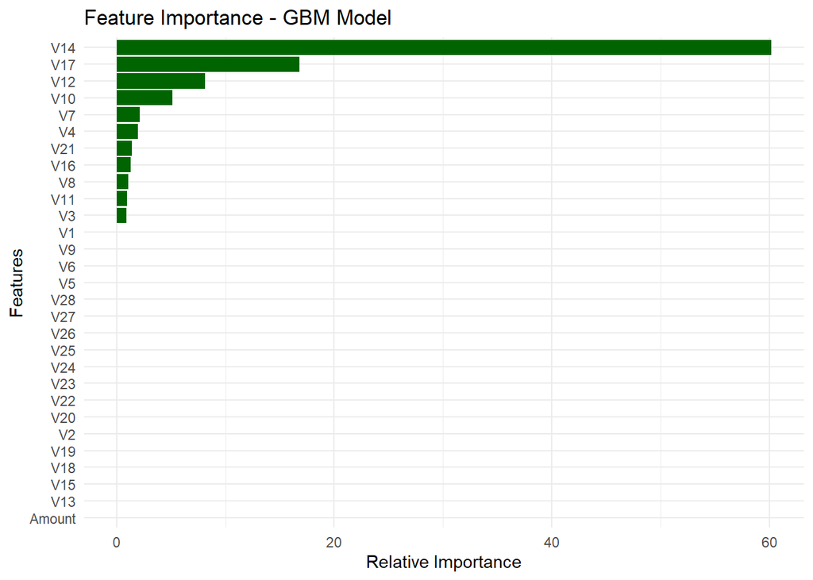

```r
# Logistic Regression
logistic_model <- glm(Class ~ ., data = train_balanced, family = binomial())

# Decision Tree
tree_model <- rpart(Class ~ ., data = train_balanced, method = "class")

# Artificial Neural Network
ann_model <- nnet(Class ~ ., data = train_balanced, size = 5, linout = FALSE, trace = FALSE, maxit = 200)

# Gradient Boosting Machine
gbm_model <- gbm(Class ~ ., distribution = "bernoulli", data = train_balanced,
                 n.trees = 300, interaction.depth = 3, shrinkage = 0.01, verbose = FALSE)

# Feature importance plot from GBM
gbm_imp <- summary(gbm_model, n.trees = 300, plotit = FALSE)
gbm_imp_df <- data.frame(Feature = gbm_imp$var, Importance = gbm_imp$rel.inf)

ggplot(gbm_imp_df, aes(x = reorder(Feature, Importance), y = Importance)) +
  geom_col(fill = "darkgreen") +
  coord_flip() +
  ggtitle("Feature Importance - GBM Model") +
  xlab("Features") +
  ylab("Relative Importance") +
  theme_minimal()
```

# 5 Model Evaluation

We define a helper function to evaluate models by producing confusion matrices and AUC scores on the test data.

```r
evaluate_model <- function(model, test_data, model_type) {
  if (model_type == "logistic") {
    probs <- predict(model, newdata = test_data, type = "response")
    preds <- ifelse(probs > 0.5, 1, 0)
  } else if (model_type == "tree") {
    preds <- predict(model, newdata = test_data, type = "class")
    probs <- predict(model, newdata = test_data)[, 2]
  } else if (model_type == "ann") {
    probs <- predict(model, newdata = test_data, type = "raw")
    preds <- ifelse(probs > 0.5, 1, 0)
  } else if (model_type == "gbm") {
    probs <- predict(model, newdata = test_data, n.trees = 300)
    preds <- ifelse(probs > 0.5, 1, 0)
  }

  cm <- confusionMatrix(factor(preds), factor(test_data$Class), positive = "1")
  auc_score <- auc(test_data$Class, as.numeric(probs))
  list(confusion_matrix = cm, auc = auc_score)
}

# Evaluate all models
logistic_eval <- evaluate_model(logistic_model, test, "logistic")
tree_eval <- evaluate_model(tree_model, test, "tree")
ann_eval <- evaluate_model(ann_model, test, "ann")
gbm_eval <- evaluate_model(gbm_model, test, "gbm")

# Show confusion matrices
logistic_eval$confusion_matrix
```

```
## Confusion Matrix and Statistics
##
##           Reference
## Prediction     0     1
##          0 56229    17
##          1   625    90
##
##                Accuracy : 0.9887
##                  95% CI : (0.9878, 0.9896)
##     No Information Rate : 0.9981
##     P-Value [Acc > NIR] : 1
##
##                   Kappa : 0.2164
##
##  Mcnemar's Test P-Value : <2e-16
##
##             Sensitivity : 0.841121
##             Specificity : 0.989007
##          Pos Pred Value : 0.125874
##          Neg Pred Value : 0.999698
##              Prevalence : 0.001878
##          Detection Rate : 0.001580
##    Detection Prevalence : 0.012552
##       Balanced Accuracy : 0.915064
##
##        'Positive' Class : 1
##
```

```r
tree_eval$confusion_matrix
```

```
## Confusion Matrix and Statistics
##
##           Reference
## Prediction     0     1
##          0 55477    18
##          1  1377    89
##
##                Accuracy : 0.9755
##                  95% CI : (0.9742, 0.9768)
##     No Information Rate : 0.9981
##     P-Value [Acc > NIR] : 1
##
##                   Kappa : 0.11
##
##  Mcnemar's Test P-Value : <2e-16
##
##             Sensitivity : 0.831776
##             Specificity : 0.975780
##          Pos Pred Value : 0.060709
##          Neg Pred Value : 0.999676
##              Prevalence : 0.001878
##          Detection Rate : 0.001562
##    Detection Prevalence : 0.025737
##       Balanced Accuracy : 0.903778
##
##        'Positive' Class : 1
##
```

```r
ann_eval$confusion_matrix
```

```
## Confusion Matrix and Statistics
##
##           Reference
## Prediction     0     1
##          0 56673    20
##          1   181    87
##
##                Accuracy : 0.9965
##                  95% CI : (0.9959, 0.9969)
##     No Information Rate : 0.9981
##     P-Value [Acc > NIR] : 1
##
##                   Kappa : 0.4626
##
##  Mcnemar's Test P-Value : <2e-16
##
##             Sensitivity : 0.813084
##             Specificity : 0.996816
##          Pos Pred Value : 0.324627
##          Neg Pred Value : 0.999647
##              Prevalence : 0.001878
##          Detection Rate : 0.001527
##    Detection Prevalence : 0.004705
##       Balanced Accuracy : 0.904950
##
##        'Positive' Class : 1
##
```

```r
gbm_eval$confusion_matrix
```

```
## Confusion Matrix and Statistics
##
##           Reference
## Prediction     0     1
##          0 56608    19
##          1   246    88
##
##                Accuracy : 0.9953
##                  95% CI : (0.9948, 0.9959)
##     No Information Rate : 0.9981
##     P-Value [Acc > NIR] : 1
##
##                   Kappa : 0.3974
##
##  Mcnemar's Test P-Value : <2e-16
##
##             Sensitivity : 0.822430
##             Specificity : 0.995673
##          Pos Pred Value : 0.263473
##          Neg Pred Value : 0.999664
##              Prevalence : 0.001878
##          Detection Rate : 0.001545
##    Detection Prevalence : 0.005864
##       Balanced Accuracy : 0.909052
##
##        'Positive' Class : 1
##
```

```r
# Aggregate AUC scores
auc_scores <- data.frame(
  Model = c("Logistic Regression", "Decision Tree", "ANN", "GBM"),
  AUC = c(logistic_eval$auc, tree_eval$auc, ann_eval$auc, gbm_eval$auc)
)

auc_scores
```

```
##                 Model       AUC
## 1 Logistic Regression 0.9823447
## 2       Decision Tree 0.9057274
## 3                 ANN 0.9585574
## 4                 GBM 0.9483702
```

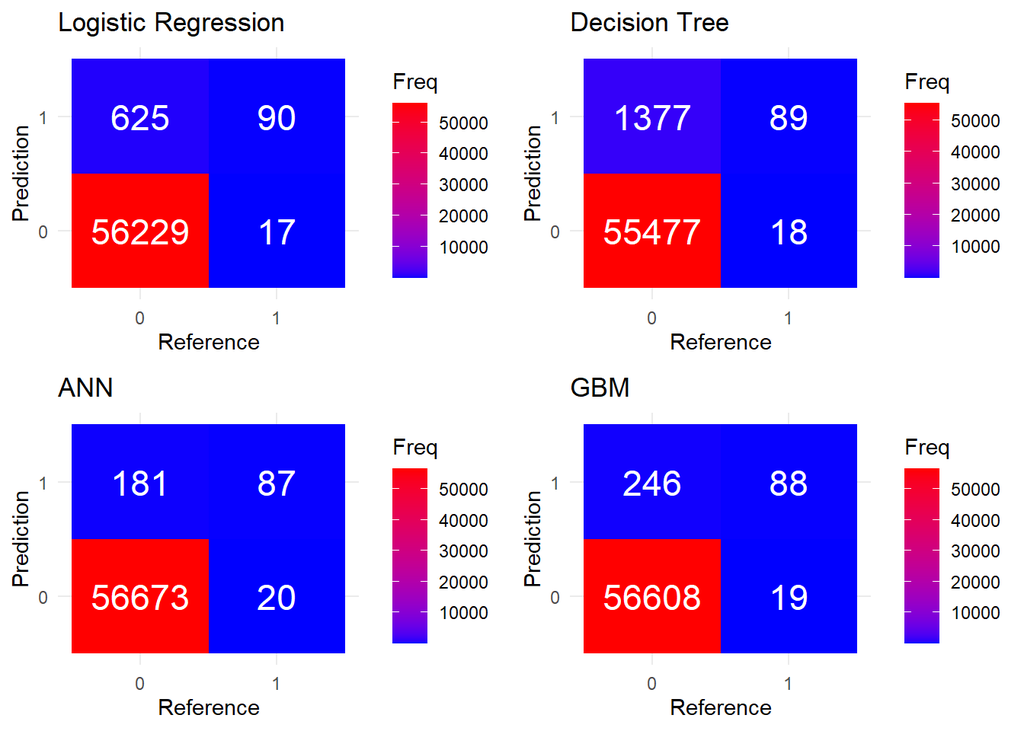

```r
library(cowplot)
library(reshape2)

plot_cm_heatmap <- function(cm, title) {
  df <- as.data.frame(cm$table)
  colnames(df) <- c("Prediction", "Reference", "Freq")

  ggplot(df, aes(x = Reference, y = Prediction, fill = Freq)) +
    geom_tile() +
    geom_text(aes(label = Freq), color = "white", size = 6) +
    scale_fill_gradient(low = "blue", high = "red") +
    labs(title = title) +
    theme_minimal()
}

p_log <- plot_cm_heatmap(logistic_eval$confusion_matrix, "Logistic Regression")
p_tree <- plot_cm_heatmap(tree_eval$confusion_matrix, "Decision Tree")
p_ann <- plot_cm_heatmap(ann_eval$confusion_matrix, "ANN")
p_gbm <- plot_cm_heatmap(gbm_eval$confusion_matrix, "GBM")

plot_grid(p_log, p_tree, p_ann, p_gbm, ncol = 2)
```

The AUC scores show Logistic Regression performed best (AUC ~0.98), closely followed by ANN. Decision Tree had the lowest performance among these models.

# 6 ROC Curves

The following ROC curves visualize each model’s performance on the test set.

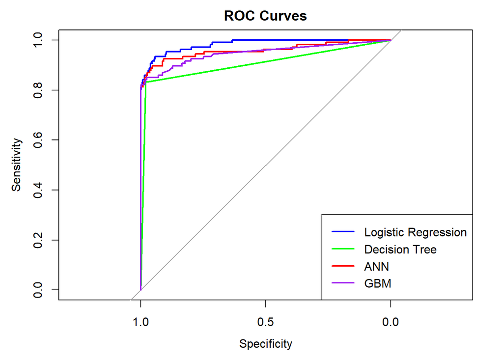

```r
roc_logistic <- roc(test$Class, predict(logistic_model, newdata = test, type = "response"))
roc_tree <- roc(test$Class, predict(tree_model, newdata = test)[, 2])
roc_ann <- roc(test$Class, predict(ann_model, newdata = test, type = "raw"))
roc_gbm <- roc(test$Class, predict(gbm_model, newdata = test, n.trees = 300))

plot(roc_logistic, col = "blue", main = "ROC Curves", lwd = 2)
plot(roc_tree, col = "green", add = TRUE, lwd = 2)
plot(roc_ann, col = "red", add = TRUE, lwd = 2)
plot(roc_gbm, col = "purple", add = TRUE, lwd = 2)

legend("bottomright", legend = c("Logistic Regression", "Decision Tree", "ANN", "GBM"),
       col = c("blue", "green", "red", "purple"), lwd = 2)
```

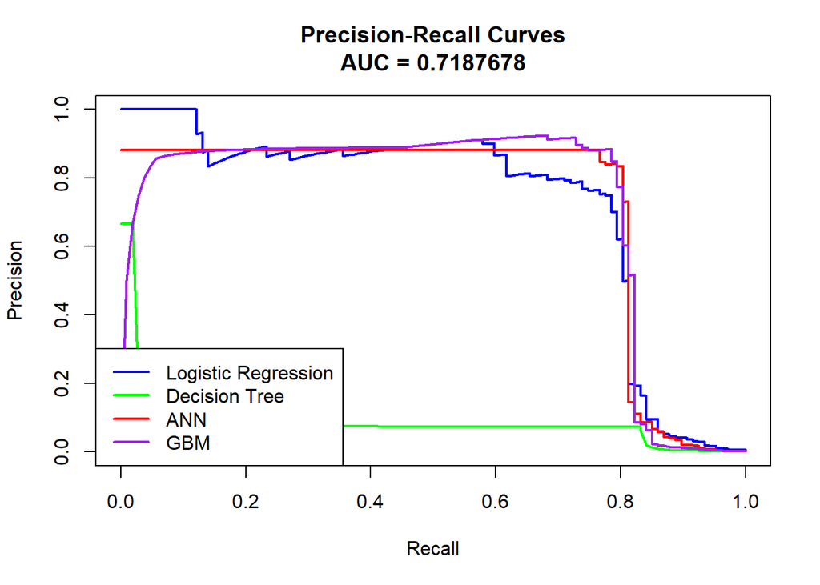

```r
# Logistic Regression
probs_logistic <- predict(logistic_model, newdata = test, type = "response")
pr_logistic <- pr.curve(scores.class0 = probs_logistic[test$Class == 1],
                       scores.class1 = probs_logistic[test$Class == 0], curve = TRUE)

# Decision Tree (probabilities for class "1")
probs_tree <- predict(tree_model, newdata = test)[, "1"]
pr_tree <- pr.curve(scores.class0 = probs_tree[test$Class == 1],
                    scores.class1 = probs_tree[test$Class == 0], curve = TRUE)

# ANN
probs_ann <- predict(ann_model, newdata = test, type = "raw")
pr_ann <- pr.curve(scores.class0 = probs_ann[test$Class == 1],
                   scores.class1 = probs_ann[test$Class == 0], curve = TRUE)

# GBM
probs_gbm <- predict(gbm_model, newdata = test, n.trees = 300, type = "response")
pr_gbm <- pr.curve(scores.class0 = probs_gbm[test$Class == 1],
                   scores.class1 = probs_gbm[test$Class == 0], curve = TRUE)

# Plot all PR curves together
plot(pr_logistic, col = "blue", main = "Precision-Recall Curves", lwd = 2)
plot(pr_tree, col = "green", add = TRUE, lwd = 2)
plot(pr_ann, col = "red", add = TRUE, lwd = 2)
plot(pr_gbm, col = "purple", add = TRUE, lwd = 2)

legend("bottomleft", legend = c("Logistic Regression", "Decision Tree", "ANN", "GBM"),
       col = c("blue", "green", "red", "purple"), lwd = 2)
```

# 7 Conclusion

Logistic Regression and Artificial Neural Network models achieved the best balance between sensitivity and specificity with high AUC scores, demonstrating strong ability to detect fraudulent transactions.

However, the dataset remains heavily imbalanced, and further improvements might be realized with techniques such as anomaly detection, ensemble methods, or cost-sensitive learning to better handle rare fraud cases in production settings.